# 3_predictions

## Initial Setup

```python
from sys import path
base_path = "/media/paulati/Nuevo vol/paula/ingebi/2020/agustina_mazzella/github/arabidopsis_phospho"
path.append(base_path)

from preparation import util
```

## Imports

```python
from os import path, remove
import pandas as pd
import numpy as np
import re
from sklearn.metrics import confusion_matrix, recall_score, precision_score
import seaborn as sns
import matplotlib.pyplot as plt
```

## Arabidopsis all ids

```python
all_arabidopsisis_file_path = path.join(base_path, "data/preproc/all_ids.zip")
all_arabidopsisis = pd.read_csv(all_arabidopsisis_file_path, header = None)
print(all_arabidopsisis.shape)
all_arabidopsisis_codes = all_arabidopsisis.iloc[:, 0].unique()
len(all_arabidopsisis_codes)
```

```
(27655, 1)
```

```
27655
```

## Experimental data

```python
experimental_file_path = path.join(base_path, "data/preproc/experimental_ids.zip")
experimental_data = pd.read_csv(experimental_file_path, sep = "\t")
experimental_data
```

|  | code |
| --- | --- |
| 0 | AT1G01050 |
| 1 | AT1G01100 |
| 2 | AT1G01320 |
| 3 | AT1G01790 |
| 4 | AT1G01960 |
| ... | ... |
| 13132 | AT5G53110 |
| 13133 | AT5G57500 |
| 13134 | AT5G62050 |
| 13135 | AT5G63590 |
| 13136 | AT5G65830 |

13137 rows × 1 columns

## Common

```python
def performance(data, score_column_name, threshold, true_value_column_name):

    if(threshold is None):
        y_pred = data[score_column_name].notnull()
    else:
        y_pred = data[score_column_name] >= threshold

    y_true = data[true_value_column_name].notnull()

    fp_mask = np.logical_and(y_pred, np.logical_not(y_true))
    fp = fp_mask.sum()

    y_pred_neg = np.logical_not(y_pred)
    y_true_neg = np.logical_not(y_true)
    tn_mask = np.logical_and(y_pred_neg, y_true_neg)
    tn = tn_mask.sum()

    fpr = fp / (fp + tn)

    tp_mask = np.logical_and(y_pred, y_true)
    tp = tp_mask.sum()

    fdr = fp / (fp + tp)

    fn_mask = np.logical_and(y_pred_neg, y_true)
    fn = fn_mask.sum()

    tpr = tp/ (tp + fn)

    matrix = confusion_matrix(y_true, y_pred)

    return fpr, tpr, matrix, fdr
```

## Phosphat

```python
phosphat_2020_file_path = path.join(base_path, "data/raw/HiconfPred_psite_20200624.zip")
data_phosphat = pd.read_csv(phosphat_2020_file_path, sep=",")
data_phosphat.head()
```

|  | code | pepposprot | c15mer |
| --- | --- | --- | --- |
| 0 | AT1G01100.4 | 102 | KDEPAEESDGDLGFG |
| 1 | AT1G01140.1 | 88 | EIIEVMASKTKIYIV |
| 2 | AT1G01200.1 | 9 | NEEMSGESPENNKHV |
| 3 | AT1G01440.1 | 44 | NRLDDSNSRPGSQRF |
| 4 | AT1G01453.2 | 182 | IEKPGNRTAVIVPTT |

```python
data_phosphat["code_unified"] = data_phosphat.code.apply(lambda x: x.split(".")[0])
data_phosphat.head()
```

|  | code | pepposprot | c15mer | code_unified |
| --- | --- | --- | --- | --- |
| 0 | AT1G01100.4 | 102 | KDEPAEESDGDLGFG | AT1G01100 |
| 1 | AT1G01140.1 | 88 | EIIEVMASKTKIYIV | AT1G01140 |
| 2 | AT1G01200.1 | 9 | NEEMSGESPENNKHV | AT1G01200 |
| 3 | AT1G01440.1 | 44 | NRLDDSNSRPGSQRF | AT1G01440 |
| 4 | AT1G01453.2 | 182 | IEKPGNRTAVIVPTT | AT1G01453 |

```python
all_phosphat_ids = data_phosphat.code_unified.unique()
len(all_phosphat_ids)
```

```
10192
```

```python
valid_phosphat_ids = [x for x in all_phosphat_ids if x in all_arabidopsisis_codes]
len(valid_phosphat_ids)
```

```
10124
```

```python
phosphat_pred = pd.DataFrame(valid_phosphat_ids, columns=["code"])
phosphat_pred_file_path = path.join(base_path, "data/preproc/phosphat_prediction_2020.csv")
#phosphat_pred.to_csv(phosphat_pred_file_path, index = False, header = True)

phosphat_pred_zip_file_path = phosphat_pred_file_path.replace(".csv", ".zip")
```

### Phosphat performance

```python
all_arabidopsisis_codes_df = pd.DataFrame(all_arabidopsisis_codes, columns = ['code'])
all_arabidopsisis_codes_df.index = all_arabidopsisis_codes_df.code
all_arabidopsisis_codes_df
```

| code | code |
| --- | --- |
| AT1G01010 | AT1G01010 |
| AT1G01020 | AT1G01020 |
| AT1G01030 | AT1G01030 |
| AT1G01040 | AT1G01040 |
| AT1G01050 | AT1G01050 |
| ... | ... |
| ATMG01350 | ATMG01350 |
| ATMG01360 | ATMG01360 |
| ATMG01370 | ATMG01370 |
| ATMG01400 | ATMG01400 |
| ATMG01410 | ATMG01410 |

27655 rows × 1 columns

```python
phosphat_pred = pd.read_csv(phosphat_pred_zip_file_path, sep= "\t")
```

```python
phosphat_pred.index = phosphat_pred.code
phosphat_pred.columns = ["code_phosphat"]
experimental_data.index = experimental_data.code
experimental_data.columns = ["code_experimental"]
phostphat_pred_exp = phosphat_pred.join(experimental_data, how = "outer")
phostphat_pred_exp_all = all_arabidopsisis_codes_df.join(phostphat_pred_exp, how = "left")
phostphat_pred_exp_all
```

| code | code | code_phosphat | code_experimental |
| --- | --- | --- | --- |
| AT1G01010 | AT1G01010 | NaN | NaN |
| AT1G01020 | AT1G01020 | NaN | NaN |
| AT1G01030 | AT1G01030 | NaN | AT1G01030 |
| AT1G01040 | AT1G01040 | AT1G01040 | AT1G01040 |
| AT1G01050 | AT1G01050 | AT1G01050 | AT1G01050 |
| ... | ... | ... | ... |
| ATMG01350 | ATMG01350 | NaN | NaN |
| ATMG01360 | ATMG01360 | NaN | NaN |
| ATMG01370 | ATMG01370 | NaN | NaN |
| ATMG01400 | ATMG01400 | NaN | NaN |
| ATMG01410 | ATMG01410 | NaN | NaN |

27655 rows × 3 columns

```python
fpr, tpr, matrix, fdr = performance(phostphat_pred_exp_all, "code_phosphat", None, "code_experimental")

print(fpr)

print(tpr)

print(matrix)

print(fdr)
```

```
0.0014464802314368371
0.7690492502093325
[[14497    21]
 [ 3034 10103]]
0.0020742789411299883
```

## Musite Deep

The value to be analyzed is **post-translational modification (PTM) score**

### Input Preparation

```python
fasta_proteins_file_path = path.join(base_path, "data/raw/Araport11_genes.201606.pep.fasta")
print(fasta_proteins_file_path)
fasta_proteins_file_path_gz = fasta_proteins_file_path + ".gz"
print(fasta_proteins_file_path_gz)

if not path.isfile(fasta_proteins_file_path):
    util.extractgz(fasta_proteins_file_path_gz, fasta_proteins_file_path)
```

```
/media/paulati/Nuevo vol/paula/ingebi/2020/agustina_mazzella/github/arabidopsis_phospho/data/raw/Araport11_genes.201606.pep.fasta
/media/paulati/Nuevo vol/paula/ingebi/2020/agustina_mazzella/github/arabidopsis_phospho/data/raw/Araport11_genes.201606.pep.fasta.gz
```

```python
lines_per_file = 7000
f_out_base_file_path = path.join(base_path,  "data/preproc/musitedeep/file{}_Araport11_genes.201606.pep.fasta")
f_out_base_file_path
```

```
'/media/paulati/Nuevo vol/paula/ingebi/2020/agustina_mazzella/github/arabidopsis_phospho/data/preproc/musitedeep/file{}_Araport11_genes.201606.pep.fasta'
```

Split fasta file in chunks of size lines_per_file to be processed by https://www.musite.net/

```python
f  = open(fasta_proteins_file_path, 'r')

current_line = ''
file_index = 1
output_lines = []

for line in f:

    if len(output_lines) < lines_per_file:
        if line[0] == '>':
            if len(current_line) > 0:
                output_lines.append(current_line)
            current_line = line
        else:
            line_clean = line.replace('\n', '')
            current_line += line
    else:
        print(len(output_lines))
        # write data to file
        out_file_path = f_out_base_file_path.format(file_index)
        print(out_file_path)
        f_out  = open(out_file_path, 'w')
        f_out.writelines(output_lines)
        f_out.close()
        file_index += 1
        output_lines = []

#save las part of sequences
print(len(output_lines))
# write data to file
out_file_path = f_out_base_file_path.format(file_index)
print(out_file_path)
f_out  = open(out_file_path, 'w')
f_out.writelines(output_lines)
f_out.close()

# close fasta input file
f.close()
remove(fasta_proteins_file_path)
```

```
7000
/media/paulati/Nuevo vol/paula/ingebi/2020/agustina_mazzella/github/arabidopsis_phospho/data/preproc/musitedeep/file1_Araport11_genes.201606.pep.fasta
7000
/media/paulati/Nuevo vol/paula/ingebi/2020/agustina_mazzella/github/arabidopsis_phospho/data/preproc/musitedeep/file2_Araport11_genes.201606.pep.fasta
7000
/media/paulati/Nuevo vol/paula/ingebi/2020/agustina_mazzella/github/arabidopsis_phospho/data/preproc/musitedeep/file3_Araport11_genes.201606.pep.fasta
7000
/media/paulati/Nuevo vol/paula/ingebi/2020/agustina_mazzella/github/arabidopsis_phospho/data/preproc/musitedeep/file4_Araport11_genes.201606.pep.fasta
7000
/media/paulati/Nuevo vol/paula/ingebi/2020/agustina_mazzella/github/arabidopsis_phospho/data/preproc/musitedeep/file5_Araport11_genes.201606.pep.fasta
7000
/media/paulati/Nuevo vol/paula/ingebi/2020/agustina_mazzella/github/arabidopsis_phospho/data/preproc/musitedeep/file6_Araport11_genes.201606.pep.fasta
6358
/media/paulati/Nuevo vol/paula/ingebi/2020/agustina_mazzella/github/arabidopsis_phospho/data/preproc/musitedeep/file7_Araport11_genes.201606.pep.fasta
```

### Results analysis

Combine all results in a single file `musiteDeep_prediction_all_file_path`

```python
musiteDeep_prediction_files_count = 7
musite_results_base_path = path.join(base_path, 'data/results/musitedeep')
musiteDeep_prediction_file_path = path.join(musite_results_base_path, 'file{}_Prediction_results.txt')
musiteDeep_prediction_all_file_path = path.join(musite_results_base_path, "Prediction_results_all.txt")
musiteDeep_prediction_all_scores_file_path = path.join(musite_results_base_path, "Prediction_results_all_scores.txt")
musiteDeep_prediction_score_by_protein_file_path = path.join(musite_results_base_path, "Prediction_results_score_by_protein.txt")
musiteDeep_prediction_score_by_id_base_file_path = path.join(musite_results_base_path, "Prediction_results_score_by_id_base.txt")

musiteDeep_prediction_all_zip_file_path = musiteDeep_prediction_all_file_path.replace(".txt", ".zip")
musiteDeep_prediction_all_scores_zip_file_path = musiteDeep_prediction_all_scores_file_path.replace(".txt", ".zip")
musiteDeep_prediction_score_by_protein_zip_file_path = musiteDeep_prediction_score_by_protein_file_path.replace(".txt", ".zip")
musiteDeep_prediction_score_by_id_base_zip_file_path = musiteDeep_prediction_score_by_id_base_file_path.replace(".txt", ".zip")
```

```python
class ScoreItem:
    def __init__(self, protein_id, prediction_type, prediction_score):
        switcher = {
            'Phosphothreonine': [protein_id, prediction_score, None, None],
            'Phosphoserine': [protein_id, None, prediction_score, None],
            'Phosphotyrosine': [protein_id, None, None, prediction_score]
            }
        self.result_row = switcher[prediction_type]

    def get_row(self):
        return self.result_row
```

```python
score_rows = []

protein_ids = []

to_discard = []

row_index = 0

for i in range(1, musiteDeep_prediction_files_count + 1):

    musiteDeep_prediction_file_path_n = musiteDeep_prediction_file_path.format(i)

    if(path.isfile(musiteDeep_prediction_file_path_n)):

        print(musiteDeep_prediction_file_path_n)

        f  = open(musiteDeep_prediction_file_path_n, 'r')

        for line in  f:

            if line[0] == '>' or line[0:2] == 'ID':
                # do nothing
                #print(line)
                to_discard.append(line)
                j = 1
            else:
                parts = line.split('\t')
                # print(parts)
                if len(parts) > 0:

                    protein_id = parts[0]

                    protein_ids.append(protein_id)

                    # column PTMscores
                    prediction = parts[len(parts) - 2]

                    prediction_parts = prediction.split(':')

                    if len(prediction_parts) > 1:

                        prediction_score = prediction_parts[1]
                        prediction_type =  prediction_parts[0]
                        score_item = ScoreItem(protein_id, prediction_type, prediction_score)
                        score_rows.append(score_item.get_row())

                    else:
                        print(prediction_parts)
                else:
                    print(parts)

        f.close()
```

```
/media/paulati/Nuevo vol/paula/ingebi/2020/agustina_mazzella/github/arabidopsis_phospho/data/results/musitedeep/file1_Prediction_results.txt
/media/paulati/Nuevo vol/paula/ingebi/2020/agustina_mazzella/github/arabidopsis_phospho/data/results/musitedeep/file2_Prediction_results.txt
/media/paulati/Nuevo vol/paula/ingebi/2020/agustina_mazzella/github/arabidopsis_phospho/data/results/musitedeep/file3_Prediction_results.txt
/media/paulati/Nuevo vol/paula/ingebi/2020/agustina_mazzella/github/arabidopsis_phospho/data/results/musitedeep/file4_Prediction_results.txt
/media/paulati/Nuevo vol/paula/ingebi/2020/agustina_mazzella/github/arabidopsis_phospho/data/results/musitedeep/file5_Prediction_results.txt
/media/paulati/Nuevo vol/paula/ingebi/2020/agustina_mazzella/github/arabidopsis_phospho/data/results/musitedeep/file6_Prediction_results.txt
/media/paulati/Nuevo vol/paula/ingebi/2020/agustina_mazzella/github/arabidopsis_phospho/data/results/musitedeep/file7_Prediction_results.txt
```

```python
scores_df = pd.DataFrame(score_rows, columns = ['protein_id', 'Phosphothreonine', 'Phosphoserine', 'Phosphotyrosine'])
```

```python
scores_df.shape
```

```
(3560696, 4)
```

```python
#scores_df.to_csv(musiteDeep_prediction_all_file_path, sep='\t', index = None)
```

Analyze `to_discard` data.

How many ids are in `to_discard` data?

```python
to_discard_ids = []

for line in to_discard:
    if line[0] == '>':
        parts = line.split('|')
        if len(parts) > 0:
            tmp = parts[0]
            id = tmp.strip()[1:len(tmp)]
            to_discard_ids.append(id)

to_discard_ids_unique = np.unique(to_discard_ids)

print(len(to_discard))
print(len(to_discard_ids_unique))
```

```
48365
48358
```

How many of theses have not any prediction in `scores_df`

(This cell takes too much time, run only when required)

```python
#for x in to_discard_ids_unique:
#    if x not in scores_df.protein_id.values:
#        print(x)
```

Ids that are included in results list but the have not score associated:

AT1G33355.1

AT1G64633.1

AT2G07617.1

AT2G21105.1

AT2G29925.1

AT5G38150.1 PLASTID MOVEMENT IMPAIRED protein (DUF827)

ATMG00665.1

> AT1G33355.1 | hypothetical protein | Chr1:12089639-12089662 FORWARD LENGTH=7 | 201606 MRKVLEN

> AT1G64633.1 | hypothetical protein | Chr1:24019584-24019586 REVERSE LENGTH=1 | 201606 M

> AT2G07617.1 | hypothetical protein | Chr2:3262540-3262563 REVERSE LENGTH=7 | 201606 MKMDGLR

> AT2G21105.1 | hypothetical protein | Chr2:9048192-9048203 FORWARD LENGTH=3 | 201606 FKD

> AT2G29925.1 | hypothetical protein | Chr2:12755040-12755237 REVERSE LENGTH=24 | 201606 MILVKWQQLKELKVKIRIWVRVLQ

This one has an score but there is a missing pipe | so that is not parsed properly:

> AT5G38150.1 PLASTID MOVEMENT IMPAIRED protein (DUF827) | Chr5:15223113-15225192 REVERSE LENGTH=1740 | 201606 MLNRAMENSDMKRNSSTLLDLPVVKSSLVVEAIHMSRKKLGWYNESRRDSETVKARVEAG LSEVKKSVEELALLIKRSNRSAGFQEKDMEVLKMEEKYAEVMRVLEVVKEEVSRVKLDVS SVLIERVAAEEKVEELRFKTEGGLRLLESLKKEIEVANEEHLMVALGKIEALKGYKEIER QREGKAIKVLDLLVERNKRIKNMLEEAERSKDIEIELFETSTDVEMLETQLKLFKKMERR VQGRDSSSMSRSNRSFGRGKYSLSVLKEVTEGKKEELASVKVEIFRVMTVMDALRNEIIR ARDETACLGKILREDDVKIEKLNSKILIEKSKLEVVSIAEERISSLAENFVGSLEKIKKS RNAAKKEEFLFKEEKTVTKAETQKTKLDIDKKESELNSKLDELEKVKHTEALVLEKLESL VEDMMESREMESEHCSTITISRFEYEYLSKHASQAEETAEKKVAAAAAWVEALKASTKSF LMKTETLMRESEMTKAEEEREVFRMERSLSTKRLVEGEIQKIKRNSEAEGYISPKPVGKF TPVQRGKPRRYSSVGTPTFFVIKKKKKVPRLAKFFSRRS

> ATMG00665.1 | NADH dehydrogenase 5B | ChrM:190740-190761 REVERSE LENGTH=7 | 201606 DMMIGLG

## Scores musiteDeep by protein

```python
data = pd.read_csv(musiteDeep_prediction_all_zip_file_path, sep='\t')

scores = data.groupby(by='protein_id').max()

protein_score_df = scores.reset_index()

protein_score_df.fillna(-1, inplace = True)

# protein_score_df.to_csv(musiteDeep_prediction_all_scores_file_path, sep = '\t', index = None)
```

```python
protein_score_df["max_score"] = protein_score_df.apply(lambda x: max(x[1], x[2], x[3]), axis=1)
protein_score_df.head()
```

|  | protein_id | Phosphothreonine | Phosphoserine | Phosphotyrosine | max_score |
| --- | --- | --- | --- | --- | --- |
| 0 | AT1G01010.1 | 0.446 | 0.788 | 0.735 | 0.788 |
| 1 | AT1G01020.1 | 0.075 | 0.741 | 0.100 | 0.741 |
| 2 | AT1G01020.2 | 0.065 | 0.741 | 0.100 | 0.741 |
| 3 | AT1G01020.3 | 0.075 | 0.741 | 0.100 | 0.741 |
| 4 | AT1G01020.4 | 0.075 | 0.741 | 0.100 | 0.741 |

```python
#protein_score_df.to_csv(musiteDeep_prediction_score_by_protein_file_path, sep='\t', index = None)
```

## Scores musiteDeep by base id

```python
score_by_protein = pd.read_csv(musiteDeep_prediction_score_by_protein_zip_file_path, sep='\t')

print(score_by_protein.shape)

score_by_protein
```

```
(48352, 5)
```

|  | protein_id | Phosphothreonine | Phosphoserine | Phosphotyrosine | max_score |
| --- | --- | --- | --- | --- | --- |
| 0 | AT1G01010.1 | 0.446 | 0.788 | 0.735 | 0.788 |
| 1 | AT1G01020.1 | 0.075 | 0.741 | 0.100 | 0.741 |
| 2 | AT1G01020.2 | 0.065 | 0.741 | 0.100 | 0.741 |
| 3 | AT1G01020.3 | 0.075 | 0.741 | 0.100 | 0.741 |
| 4 | AT1G01020.4 | 0.075 | 0.741 | 0.100 | 0.741 |
| ... | ... | ... | ... | ... | ... |
| 48347 | ATMG01330.1 | 0.285 | 0.875 | 0.204 | 0.875 |
| 48348 | ATMG01350.1 | 0.695 | 0.583 | 0.249 | 0.695 |
| 48349 | ATMG01360.1 | 0.151 | 0.298 | 0.438 | 0.438 |
| 48350 | ATMG01370.1 | 0.191 | 0.624 | 0.261 | 0.624 |
| 48351 | ATMG01400.1 | 0.589 | 0.912 | 0.355 | 0.912 |

48352 rows × 5 columns

```python
def get_id_base(data):

    parts = data.split('.')

    if len(parts) > 0:
        id_base = parts[0]
    else:
        id_base = data

    return(id_base)
```

```python
score_by_protein["protein_id_base"] = score_by_protein.apply(lambda x: get_id_base(x['protein_id']), axis = 1)
```

```python
print(score_by_protein.shape)
score_by_protein
```

```
(48352, 6)
```

|  | protein_id | Phosphothreonine | Phosphoserine | Phosphotyrosine | max_score | protein_id_base |
| --- | --- | --- | --- | --- | --- | --- |
| 0 | AT1G01010.1 | 0.446 | 0.788 | 0.735 | 0.788 | AT1G01010 |
| 1 | AT1G01020.1 | 0.075 | 0.741 | 0.100 | 0.741 | AT1G01020 |
| 2 | AT1G01020.2 | 0.065 | 0.741 | 0.100 | 0.741 | AT1G01020 |
| 3 | AT1G01020.3 | 0.075 | 0.741 | 0.100 | 0.741 | AT1G01020 |
| 4 | AT1G01020.4 | 0.075 | 0.741 | 0.100 | 0.741 | AT1G01020 |
| ... | ... | ... | ... | ... | ... | ... |
| 48347 | ATMG01330.1 | 0.285 | 0.875 | 0.204 | 0.875 | ATMG01330 |
| 48348 | ATMG01350.1 | 0.695 | 0.583 | 0.249 | 0.695 | ATMG01350 |
| 48349 | ATMG01360.1 | 0.151 | 0.298 | 0.438 | 0.438 | ATMG01360 |
| 48350 | ATMG01370.1 | 0.191 | 0.624 | 0.261 | 0.624 | ATMG01370 |
| 48351 | ATMG01400.1 | 0.589 | 0.912 | 0.355 | 0.912 | ATMG01400 |

48352 rows × 6 columns

There is not any max_score null:

```python
(score_by_protein.max_score == -1).sum()
```

```
0
```

```python
max_values = pd.DataFrame(score_by_protein.groupby('protein_id_base')['max_score'].max())
max_values = max_values.rename(columns={"max_score": "max_value"})

min_values = pd.DataFrame(score_by_protein.groupby('protein_id_base')['max_score'].min())
min_values = min_values.rename(columns={"max_score": "min_value"})

mean_values = pd.DataFrame(score_by_protein.groupby('protein_id_base')['max_score'].mean())
mean_values = mean_values.rename(columns={"max_score": "mean_value"})
```

```python
tmp1 = min_values.join(max_values, how="outer")
score_by_id_base = tmp1.join(mean_values, how="outer")
```

```python
score_by_id_base.reset_index(inplace = True)
score_by_id_base.columns = ['protein_id_base','min_score','max_score', 'mean_score']
score_by_id_base
```

|  | protein_id_base | min_score | max_score | mean_score |
| --- | --- | --- | --- | --- |
| 0 | AT1G01010 | 0.788 | 0.788 | 0.788000 |
| 1 | AT1G01020 | 0.263 | 0.741 | 0.661333 |
| 2 | AT1G01030 | 0.836 | 0.836 | 0.836000 |
| 3 | AT1G01040 | 0.882 | 0.882 | 0.882000 |
| 4 | AT1G01050 | 0.786 | 0.786 | 0.786000 |
| ... | ... | ... | ... | ... |
| 27643 | ATMG01330 | 0.875 | 0.875 | 0.875000 |
| 27644 | ATMG01350 | 0.695 | 0.695 | 0.695000 |
| 27645 | ATMG01360 | 0.438 | 0.438 | 0.438000 |
| 27646 | ATMG01370 | 0.624 | 0.624 | 0.624000 |
| 27647 | ATMG01400 | 0.912 | 0.912 | 0.912000 |

27648 rows × 4 columns

Checking all ids are valid

```python
all([x in all_arabidopsisis_codes for x in score_by_id_base.protein_id_base])
```

```
True
```

```python
#score_by_id_base.to_csv(musiteDeep_prediction_score_by_id_base_file_path, sep= "\t", index = False, header = True)
```

## Join MusiteDeep scores by base id - Experimental data

```python
musite_scores_file_path = musiteDeep_prediction_score_by_id_base_file_path.replace(".txt", ".zip")
musite_scores_data = pd.read_csv(musite_scores_file_path, sep = "\t")
musite_scores_data
```

|  | protein_id_base | min_score | max_score | mean_score |
| --- | --- | --- | --- | --- |
| 0 | AT1G01010 | 0.788 | 0.788 | 0.788000 |
| 1 | AT1G01020 | 0.263 | 0.741 | 0.661333 |
| 2 | AT1G01030 | 0.836 | 0.836 | 0.836000 |
| 3 | AT1G01040 | 0.882 | 0.882 | 0.882000 |
| 4 | AT1G01050 | 0.786 | 0.786 | 0.786000 |
| ... | ... | ... | ... | ... |
| 27643 | ATMG01330 | 0.875 | 0.875 | 0.875000 |
| 27644 | ATMG01350 | 0.695 | 0.695 | 0.695000 |
| 27645 | ATMG01360 | 0.438 | 0.438 | 0.438000 |
| 27646 | ATMG01370 | 0.624 | 0.624 | 0.624000 |
| 27647 | ATMG01400 | 0.912 | 0.912 | 0.912000 |

27648 rows × 4 columns

```python
musite_scores_data.index = musite_scores_data.protein_id_base
#experimental_data.index = experimental_data.code
musite_experimental_data = musite_scores_data.join(experimental_data, how = "outer")
musite_experimental_data
```

|  | protein_id_base | min_score | max_score | mean_score | code_experimental |
| --- | --- | --- | --- | --- | --- |
| AT1G01010 | AT1G01010 | 0.788 | 0.788 | 0.788000 | NaN |
| AT1G01020 | AT1G01020 | 0.263 | 0.741 | 0.661333 | NaN |
| AT1G01030 | AT1G01030 | 0.836 | 0.836 | 0.836000 | AT1G01030 |
| AT1G01040 | AT1G01040 | 0.882 | 0.882 | 0.882000 | AT1G01040 |
| AT1G01050 | AT1G01050 | 0.786 | 0.786 | 0.786000 | AT1G01050 |
| ... | ... | ... | ... | ... | ... |
| ATMG01330 | ATMG01330 | 0.875 | 0.875 | 0.875000 | NaN |
| ATMG01350 | ATMG01350 | 0.695 | 0.695 | 0.695000 | NaN |
| ATMG01360 | ATMG01360 | 0.438 | 0.438 | 0.438000 | NaN |
| ATMG01370 | ATMG01370 | 0.624 | 0.624 | 0.624000 | NaN |
| ATMG01400 | ATMG01400 | 0.912 | 0.912 | 0.912000 | NaN |

27648 rows × 5 columns

```python
musite_experimental_data["label"] = [1 if x is not np.NaN else 0 for x in musite_experimental_data.code_experimental.values]
musite_experimental_data["color"] = ["orange" if x == 1 else "blue" for x in musite_experimental_data.label.values]
```

```python
musite_experimental_data
```

|  | protein_id_base | min_score | max_score | mean_score | code_experimental | label | color |
| --- | --- | --- | --- | --- | --- | --- | --- |
| AT1G01010 | AT1G01010 | 0.788 | 0.788 | 0.788000 | NaN | 0 | blue |
| AT1G01020 | AT1G01020 | 0.263 | 0.741 | 0.661333 | NaN | 0 | blue |
| AT1G01030 | AT1G01030 | 0.836 | 0.836 | 0.836000 | AT1G01030 | 1 | orange |
| AT1G01040 | AT1G01040 | 0.882 | 0.882 | 0.882000 | AT1G01040 | 1 | orange |
| AT1G01050 | AT1G01050 | 0.786 | 0.786 | 0.786000 | AT1G01050 | 1 | orange |
| ... | ... | ... | ... | ... | ... | ... | ... |
| ATMG01330 | ATMG01330 | 0.875 | 0.875 | 0.875000 | NaN | 0 | blue |
| ATMG01350 | ATMG01350 | 0.695 | 0.695 | 0.695000 | NaN | 0 | blue |
| ATMG01360 | ATMG01360 | 0.438 | 0.438 | 0.438000 | NaN | 0 | blue |
| ATMG01370 | ATMG01370 | 0.624 | 0.624 | 0.624000 | NaN | 0 | blue |
| ATMG01400 | ATMG01400 | 0.912 | 0.912 | 0.912000 | NaN | 0 | blue |

27648 rows × 7 columns

```python
score_threshold = 0.85 # from notebook roc.ipynb
```

```python
musite_experimental_data['prediction'] = 0
mask = musite_experimental_data.max_score >= score_threshold
musite_experimental_data.loc[mask, 'prediction'] = 1
columns = ['protein_id_base', 'max_score', 'prediction']
musite_prediction = musite_experimental_data[columns]
musite_prediction
```

|  | protein_id_base | max_score | prediction |
| --- | --- | --- | --- |
| AT1G01010 | AT1G01010 | 0.788 | 0 |
| AT1G01020 | AT1G01020 | 0.741 | 0 |
| AT1G01030 | AT1G01030 | 0.836 | 0 |
| AT1G01040 | AT1G01040 | 0.882 | 1 |
| AT1G01050 | AT1G01050 | 0.786 | 0 |
| ... | ... | ... | ... |
| ATMG01330 | ATMG01330 | 0.875 | 1 |
| ATMG01350 | ATMG01350 | 0.695 | 0 |
| ATMG01360 | ATMG01360 | 0.438 | 0 |
| ATMG01370 | ATMG01370 | 0.624 | 0 |
| ATMG01400 | ATMG01400 | 0.912 | 1 |

27648 rows × 3 columns

```python
musite_prediction_file_path = path.join(base_path, "data/results/musitedeep/musiteDeep_prediction_thr.txt")
#musite_prediction.to_csv(musite_prediction_file_path, sep="\t", index = None, header = True)
```

```python
len(musite_prediction.protein_id_base.unique())
```

```
27648
```

```python
len(all_arabidopsisis_codes)
```

```
27655
```

There are 7 (27655 - 27648) ids not scored by musiteDeep

### MusiteDeep performance

#### threshold = 0.5

```python
fpr_05, tpr_05, matrix_05, fdr_05 = performance(musite_experimental_data, "max_score", 0.5, "code_experimental")
print(fpr_05)
print(tpr_05)
print(matrix_05)
print(fdr_05)
```

```
0.9073116945765282
0.9921595493643907
[[ 1345 13166]
 [  103 13034]]
0.5025190839694657
```

#### threshold = 0.85

```python
fpr_085, tpr_085, matrix_085, fdr_085 = performance(musite_experimental_data, "max_score", 0.85, "code_experimental")
print(fpr_085)
print(tpr_085)
print(matrix_085)
print(fdr_085)
```

```
0.35269795327682446
0.6875237877749867
[[9393 5118]
 [4105 9032]]
0.36169611307420496
```

## PredOr: phosphat + musiteDeep

```python
musite_prediction_file_path = path.join(base_path, "data/results/musitedeep/musiteDeep_prediction_thr.zip")
musite_prediction = pd.read_csv(musite_prediction_file_path, sep="\t")
musite_prediction
```

|  | protein_id_base | max_score | prediction |
| --- | --- | --- | --- |
| 0 | AT1G01010 | 0.788 | 0 |
| 1 | AT1G01020 | 0.741 | 0 |
| 2 | AT1G01030 | 0.836 | 0 |
| 3 | AT1G01040 | 0.882 | 1 |
| 4 | AT1G01050 | 0.786 | 0 |
| ... | ... | ... | ... |
| 27643 | ATMG01330 | 0.875 | 1 |
| 27644 | ATMG01350 | 0.695 | 0 |
| 27645 | ATMG01360 | 0.438 | 0 |
| 27646 | ATMG01370 | 0.624 | 0 |
| 27647 | ATMG01400 | 0.912 | 1 |

27648 rows × 3 columns

```python
musite_prediction.prediction.sum()
```

```
14150
```

```python
phosphat_pred_file_path = path.join(base_path, "data/preproc/phosphat_prediction_2020.zip")
phosphat_pred =  pd.read_csv(phosphat_pred_file_path, sep="\t")
phosphat_pred.index = phosphat_pred.code
phosphat_pred
```

| code | code |
| --- | --- |
| AT1G01100 | AT1G01100 |
| AT1G01140 | AT1G01140 |
| AT1G01200 | AT1G01200 |
| AT1G01440 | AT1G01440 |
| AT1G01453 | AT1G01453 |
| ... | ... |
| AT5G53780 | AT5G53780 |
| AT5G58620 | AT5G58620 |
| AT5G58850 | AT5G58850 |
| AT5G60790 | AT5G60790 |
| ATMG01090 | ATMG01090 |

10124 rows × 1 columns

```python
musite_prediction_mask = musite_prediction.prediction == 1
musite_pred = musite_prediction.loc[musite_prediction_mask, 'protein_id_base'].values
predOr = np.concatenate([musite_pred, phosphat_pred.code.values])
predOr_result = pd.DataFrame(np.unique(predOr), columns = ['code'])
predOr_result
```

|  | code |
| --- | --- |
| 0 | AT1G01040 |
| 1 | AT1G01050 |
| 2 | AT1G01060 |
| 3 | AT1G01070 |
| 4 | AT1G01080 |
| ... | ... |
| 17151 | ATMG01260 |
| 17152 | ATMG01280 |
| 17153 | ATMG01290 |
| 17154 | ATMG01330 |
| 17155 | ATMG01400 |

17156 rows × 1 columns

```python
all_valid_codes = len(np.unique([x for x in predOr_result.code if x in all_arabidopsisis_codes])) == predOr_result.shape[0]
all_valid_codes
```

```
True
```

```python
predOr_file_path_out = path.join(base_path, "data/results/predOr_phosphat_musiteDeep.csv")
#predOr_result.to_csv(predOr_file_path_out, index = None)
```

Combining musiteDeep and Phosphat results

```python
result = musite_prediction.loc[musite_prediction_mask, :]
result.index = result.protein_id_base
phosphat_musitedeep = result.join(phosphat_pred, lsuffix = '_musitedeep', rsuffix='_phosphat', how="outer")
phosphat_musitedeep
```

|  | protein_id_base | max_score | prediction | code |
| --- | --- | --- | --- | --- |
| AT1G01040 | AT1G01040 | 0.882 | 1.0 | AT1G01040 |
| AT1G01050 | NaN | NaN | NaN | AT1G01050 |
| AT1G01060 | AT1G01060 | 0.881 | 1.0 | AT1G01060 |
| AT1G01070 | AT1G01070 | 0.895 | 1.0 | NaN |
| AT1G01080 | NaN | NaN | NaN | AT1G01080 |
| ... | ... | ... | ... | ... |
| ATMG01260 | NaN | NaN | NaN | ATMG01260 |
| ATMG01280 | ATMG01280 | 0.869 | 1.0 | NaN |
| ATMG01290 | ATMG01290 | 0.888 | 1.0 | ATMG01290 |
| ATMG01330 | ATMG01330 | 0.875 | 1.0 | NaN |
| ATMG01400 | ATMG01400 | 0.912 | 1.0 | NaN |

17156 rows × 4 columns

How many musite predicted positive are not in phospaht predicted?

```python
mask_1 = pd.notnull(phosphat_musitedeep.protein_id_base).values & pd.isnull(phosphat_musitedeep.code).values
mask_1.sum()
```

```
7032
```

How many phosphat predicted positive are not in musite predicted?

```python
mask_2 = pd.isnull(phosphat_musitedeep.protein_id_base).values & pd.notnull(phosphat_musitedeep.code).values
mask_2.sum()
```

```
3006
```

## PredOr performance metrics

```python
#predOr_file_path = path.join(base_path, "data/results/predOr_phosphat_musiteDeep.zip")
predOr_file_path = path.join(base_path, "data/results/PredRS.zip")
predOr_data = pd.read_csv(predOr_file_path)
predOr_data.index = predOr_data.code
predOr_data
```

| code | code |
| --- | --- |
| AT1G01040 | AT1G01040 |
| AT1G01050 | AT1G01050 |
| AT1G01060 | AT1G01060 |
| AT1G01070 | AT1G01070 |
| AT1G01080 | AT1G01080 |
| ... | ... |
| ATMG01260 | ATMG01260 |
| ATMG01280 | ATMG01280 |
| ATMG01290 | ATMG01290 |
| ATMG01330 | ATMG01330 |
| ATMG01400 | ATMG01400 |

17156 rows × 1 columns

```python
all_arabidopsisis_codes
```

```
array(['AT1G01010', 'AT1G01020', 'AT1G01030', ..., 'ATMG01370',
       'ATMG01400', 'ATMG01410'], dtype=object)
```

```python
experimental_data
```

| code | code_experimental |
| --- | --- |
| AT1G01050 | AT1G01050 |
| AT1G01100 | AT1G01100 |
| AT1G01320 | AT1G01320 |
| AT1G01790 | AT1G01790 |
| AT1G01960 | AT1G01960 |
| ... | ... |
| AT5G53110 | AT5G53110 |
| AT5G57500 | AT5G57500 |
| AT5G62050 | AT5G62050 |
| AT5G63590 | AT5G63590 |
| AT5G65830 | AT5G65830 |

13137 rows × 1 columns

```python
exp_predOr = pd.DataFrame(all_arabidopsisis_codes, columns = ["arabidopsisis_codes"])
exp_predOr.index = exp_predOr.arabidopsisis_codes
print(exp_predOr.shape)
exp_predOr = exp_predOr.join(predOr_data, how = 'left', lsuffix = "_arabidopsis", rsuffix = "_predOr")
exp_predOr = exp_predOr.join(experimental_data, how = 'left', lsuffix = "_predOr", rsuffix = "_exp")

y_true_mask = [1 if x else 0 for x in pd.notnull(exp_predOr.code_experimental)]
exp_predOr["y_true"] = y_true_mask
y_pred_mask = [1 if x else 0 for x in pd.notnull(exp_predOr.code)]
exp_predOr["y_pred"] = y_pred_mask
exp_predOr
```

```
(27655, 1)
```

| arabidopsisis_codes | arabidopsisis_codes | code | code_experimental | y_true | y_pred |
| --- | --- | --- | --- | --- | --- |
| AT1G01010 | AT1G01010 | NaN | NaN | 0 | 0 |
| AT1G01020 | AT1G01020 | NaN | NaN | 0 | 0 |
| AT1G01030 | AT1G01030 | NaN | AT1G01030 | 1 | 0 |
| AT1G01040 | AT1G01040 | AT1G01040 | AT1G01040 | 1 | 1 |
| AT1G01050 | AT1G01050 | AT1G01050 | AT1G01050 | 1 | 1 |
| ... | ... | ... | ... | ... | ... |
| ATMG01350 | ATMG01350 | NaN | NaN | 0 | 0 |
| ATMG01360 | ATMG01360 | NaN | NaN | 0 | 0 |
| ATMG01370 | ATMG01370 | NaN | NaN | 0 | 0 |
| ATMG01400 | ATMG01400 | ATMG01400 | NaN | 0 | 1 |
| ATMG01410 | ATMG01410 | NaN | NaN | 0 | 0 |

27655 rows × 5 columns

```python
conf_matrix = confusion_matrix(exp_predOr.y_true, exp_predOr.y_pred)
print(conf_matrix)

predOR_recall = recall_score(exp_predOr.y_true, exp_predOr.y_pred)
print(predOR_recall)

predOR_precision = precision_score(exp_predOr.y_true, exp_predOr.y_pred)
print(predOR_precision)
```

```
[[ 9386  5132]
 [ 1113 12024]]
0.9152774606074446
0.7008626719515039
```

```python
tn, fp, fn, tp = conf_matrix.ravel()

specificity = tn / (tn + fp)
specificity
```

```
0.6465077834412454
```

```python
# false positive rate

fpr = fp / (fp + tn)
fpr
```

```
0.3534922165587546
```

```python
fpr, tpr, matrix, fdr = performance(exp_predOr, "code", None, "code_experimental")
print(fpr)
print(tpr)
print(matrix)
print(fdr)
```

```
0.3534922165587546
0.9152774606074446
[[ 9386  5132]
 [ 1113 12024]]
0.29913732804849613
```

## Why do we have combined a good performance predictor as phosphat with a not so good as musiteDeep

**The idea is to get a prediction that predict as positive a geater number of ids that already have experimental evidence**

Confusion matrix whose i-th row and j-th column entry indicates the number of samples with true label being i-th class and predicted label being j-th class.

**Phosphat** confusion matrix is

$\begin{matrix}14497 & 21 \\ 3034 & 10103 \end{matrix}$

fpr 0.0014464802314368371

tpr 0.7690492502093325

**PredOr** confusion matrix is

$\begin{matrix}9386 & 5132 \\ 1113 & 12024 \end{matrix}$

## Experimental evidence and not predicted as phosphorylated

There are 1113 ids predicted as negative that have experimental evidence

What are they scores?

How does metrics change if they are included as positives by musiteDeep?

```python
ids_1113_mask = np.logical_and(exp_predOr.y_true == 1, exp_predOr.y_pred == 0)
ids_1113 = exp_predOr.loc[ids_1113_mask, 'arabidopsisis_codes'].values
ids_1113
```

```
array(['AT1G01030', 'AT1G01340', 'AT1G01430', ..., 'ATCG00800',
       'ATCG01070', 'ATMG00810'], dtype=object)
```

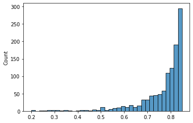

```python
ids_1113_mask = [x in ids_1113 for x in musite_prediction.protein_id_base]
scores = musite_prediction.loc[ids_1113_mask, 'max_score'].values
sns.histplot(scores)
```

```python
min(scores)
```

```
0.199
```

ids_1113 included in phosphat prediction?:

```python
[x for x in ids_1113 if x in phosphat_pred.code.values]
```

```
[]
```

# How do metrics vary with differente musite threshold?

```python
experimental_file_path = path.join(base_path, "data/preproc/experimental_ids.zip")
experimental_data = pd.read_csv(experimental_file_path, sep = "\t")
experimental_data.index = experimental_data.code
experimental_data
```

| code | code |
| --- | --- |
| AT1G01050 | AT1G01050 |
| AT1G01100 | AT1G01100 |
| AT1G01320 | AT1G01320 |
| AT1G01790 | AT1G01790 |
| AT1G01960 | AT1G01960 |
| ... | ... |
| AT5G53110 | AT5G53110 |
| AT5G57500 | AT5G57500 |
| AT5G62050 | AT5G62050 |
| AT5G63590 | AT5G63590 |
| AT5G65830 | AT5G65830 |

13137 rows × 1 columns

```python
musite_scores_file_path = musiteDeep_prediction_score_by_id_base_file_path.replace(".txt", ".zip")
musite_scores_data = pd.read_csv(musite_scores_file_path, sep = "\t")
musite_scores_data.index = musite_scores_data.protein_id_base
musite_scores_data = musite_scores_data[["protein_id_base", "max_score" ]]
musite_scores_data
```

| protein_id_base | protein_id_base | max_score |
| --- | --- | --- |
| AT1G01010 | AT1G01010 | 0.788 |
| AT1G01020 | AT1G01020 | 0.741 |
| AT1G01030 | AT1G01030 | 0.836 |
| AT1G01040 | AT1G01040 | 0.882 |
| AT1G01050 | AT1G01050 | 0.786 |
| ... | ... | ... |
| ATMG01330 | ATMG01330 | 0.875 |
| ATMG01350 | ATMG01350 | 0.695 |
| ATMG01360 | ATMG01360 | 0.438 |
| ATMG01370 | ATMG01370 | 0.624 |
| ATMG01400 | ATMG01400 | 0.912 |

27648 rows × 2 columns

```python
phosphat_pred_file_path = path.join(base_path, "data/preproc/phosphat_prediction_2020.zip")
phosphat_pred =  pd.read_csv(phosphat_pred_file_path, sep="\t")
phosphat_pred.index = phosphat_pred.code
phosphat_pred
```

| code | code |
| --- | --- |
| AT1G01100 | AT1G01100 |
| AT1G01140 | AT1G01140 |
| AT1G01200 | AT1G01200 |
| AT1G01440 | AT1G01440 |
| AT1G01453 | AT1G01453 |
| ... | ... |
| AT5G53780 | AT5G53780 |
| AT5G58620 | AT5G58620 |
| AT5G58850 | AT5G58850 |
| AT5G60790 | AT5G60790 |
| ATMG01090 | ATMG01090 |

10124 rows × 1 columns

```python
all_data = pd.DataFrame(all_arabidopsisis_codes, columns = ["arabidopsisis_codes"])
all_data.index = all_data.arabidopsisis_codes
experimental_data.columns = ["code_exp"]
all_data = all_data.join(experimental_data, how = "left")
musite_scores_data.columns = ["code_musite", "score_musite"]
all_data = all_data.join(musite_scores_data, how = "left")
phosphat_pred.columns = ["code_phosphat"]
all_data = all_data.join(phosphat_pred, how = "left")
all_data
```

| arabidopsisis_codes | arabidopsisis_codes | code_exp | code_musite | score_musite | code_phosphat |
| --- | --- | --- | --- | --- | --- |
| AT1G01010 | AT1G01010 | NaN | AT1G01010 | 0.788 | NaN |
| AT1G01020 | AT1G01020 | NaN | AT1G01020 | 0.741 | NaN |
| AT1G01030 | AT1G01030 | AT1G01030 | AT1G01030 | 0.836 | NaN |
| AT1G01040 | AT1G01040 | AT1G01040 | AT1G01040 | 0.882 | AT1G01040 |
| AT1G01050 | AT1G01050 | AT1G01050 | AT1G01050 | 0.786 | AT1G01050 |
| ... | ... | ... | ... | ... | ... |
| ATMG01350 | ATMG01350 | NaN | ATMG01350 | 0.695 | NaN |
| ATMG01360 | ATMG01360 | NaN | ATMG01360 | 0.438 | NaN |
| ATMG01370 | ATMG01370 | NaN | ATMG01370 | 0.624 | NaN |
| ATMG01400 | ATMG01400 | NaN | ATMG01400 | 0.912 | NaN |
| ATMG01410 | ATMG01410 | NaN | NaN | NaN | NaN |

27655 rows × 5 columns

```python
len(all_arabidopsisis_codes) == all_data.shape[0]
```

```
True
```

```python
y_true_mask = [1 if x else 0 for x in pd.notnull(all_data.code_exp)]
all_data["y_true"] = y_true_mask
all_data
```

| arabidopsisis_codes | arabidopsisis_codes | code_exp | code_musite | score_musite | code_phosphat | y_true |
| --- | --- | --- | --- | --- | --- | --- |
| AT1G01010 | AT1G01010 | NaN | AT1G01010 | 0.788 | NaN | 0 |
| AT1G01020 | AT1G01020 | NaN | AT1G01020 | 0.741 | NaN | 0 |
| AT1G01030 | AT1G01030 | AT1G01030 | AT1G01030 | 0.836 | NaN | 1 |
| AT1G01040 | AT1G01040 | AT1G01040 | AT1G01040 | 0.882 | AT1G01040 | 1 |
| AT1G01050 | AT1G01050 | AT1G01050 | AT1G01050 | 0.786 | AT1G01050 | 1 |
| ... | ... | ... | ... | ... | ... | ... |
| ATMG01350 | ATMG01350 | NaN | ATMG01350 | 0.695 | NaN | 0 |
| ATMG01360 | ATMG01360 | NaN | ATMG01360 | 0.438 | NaN | 0 |
| ATMG01370 | ATMG01370 | NaN | ATMG01370 | 0.624 | NaN | 0 |
| ATMG01400 | ATMG01400 | NaN | ATMG01400 | 0.912 | NaN | 0 |
| ATMG01410 | ATMG01410 | NaN | NaN | NaN | NaN | 0 |

27655 rows × 6 columns

```python
threshold_count = 100

pred_recalls = []
pred_precisions = []
pred_specificities = []
false_negatives = []
true_negatives = []
false_positives = []
true_positives = []
fprs = []

min_thr = 0
#min_thr = 50

for i in range(min_thr, threshold_count):
    threshold = i / threshold_count

    pred_mask = np.logical_or(all_data.score_musite >= threshold, pd.notnull(all_data.code_phosphat))
    y_pred_values = [1 if x else 0 for x in pred_mask.values]
    all_data["y_pred"] = y_pred_values

    pred_recall = recall_score(all_data.y_true, all_data.y_pred)
    #print(predOR_recall)
    pred_recalls.append(pred_recall)

    pred_precision = precision_score(all_data.y_true, all_data.y_pred)
    #print(predOR_precision)
    pred_precisions.append(pred_precision)

    conf_matrix = confusion_matrix(all_data.y_true, all_data.y_pred)
    #print(conf_matrix)
    tn, fp, fn, tp = conf_matrix.ravel()
    false_negatives.append(fn)
    false_positives.append(fp)
    true_negatives.append(tn)
    true_positives.append(tp)

    pred_specificity = tn / (tn + fp)
    pred_specificities.append(pred_specificity)

    fpr = fp / (fp + tn)
    fprs.append(fpr)
```

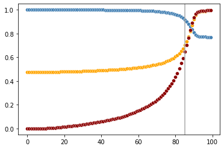

```python
# how many relevant items (positives) are selected?
sns.scatterplot(x = range(min_thr, threshold_count), y = pred_recalls, color = "steelblue")

# how many seleted items are relevant?
sns.scatterplot(x = range(min_thr, threshold_count), y = pred_precisions, color = "orange")

# tn / (tn + fp)
sns.scatterplot(x = range(min_thr, threshold_count), y = pred_specificities, color = "darkred")

plt.axvline(x = 85, ymin = 0, ymax = 1, color = "darkgrey")
```

```python
max(false_negatives)
```

```
3034
```

```python
max(false_positives)
```

```
14511
```

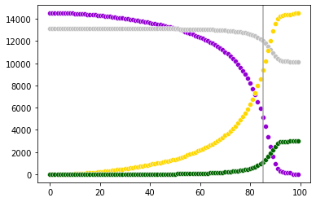

```python
#false_positives_rel = false_positives / max(false_positives)
sns.scatterplot(x = range(min_thr, threshold_count), y = false_positives, color = "darkviolet")

sns.scatterplot(x = range(min_thr, threshold_count), y = true_positives, color = "silver")

sns.scatterplot(x = range(min_thr, threshold_count), y = true_negatives, color = "gold")

#false_negatives_rel = false_negatives / max(false_negatives)
sns.scatterplot(x = range(min_thr, threshold_count), y = false_negatives, color = "darkgreen")

plt.axvline(x = 85, ymin = 0, ymax = 1, color = "darkgrey")
```

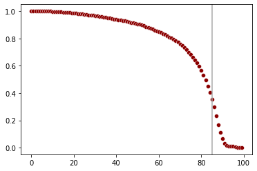

```python
sns.scatterplot(x = range(min_thr, threshold_count), y = fprs, color = "darkred")
plt.axvline(x = 85, ymin = 0, ymax = 1, color = "darkgrey")
```

```python
score_min_1113 = min(scores)
print(score_min_1113)
```

```
0.199
```